# Lab8

Alp Tutkun

4/4/2020

# coding principles

## anova

### s1: formulate model for simulated data

```r
my.df <- data.frame(response=c(rnorm(30,mean=1.1),rnorm(30,mean=1), rnorm(30,mean=2)),treatment=rep(c("T1","T2","T3"),each=30))
head(my.df)
```

```
##     response treatment
## 1 0.01502456        T1
## 2 1.86086330        T1
## 3 1.43556994        T1
## 4 0.94093388        T1
## 5 3.37515387        T1
## 6 0.79732607        T1
```

```r
str(my.df)
```

```
## 'data.frame':    90 obs. of  2 variables:
##  $ response : num  0.015 1.861 1.436 0.941 3.375 ...
##  $ treatment: Factor w/ 3 levels "T1","T2","T3": 1 1 1 1 1 1 1 1 1 1 ...
```

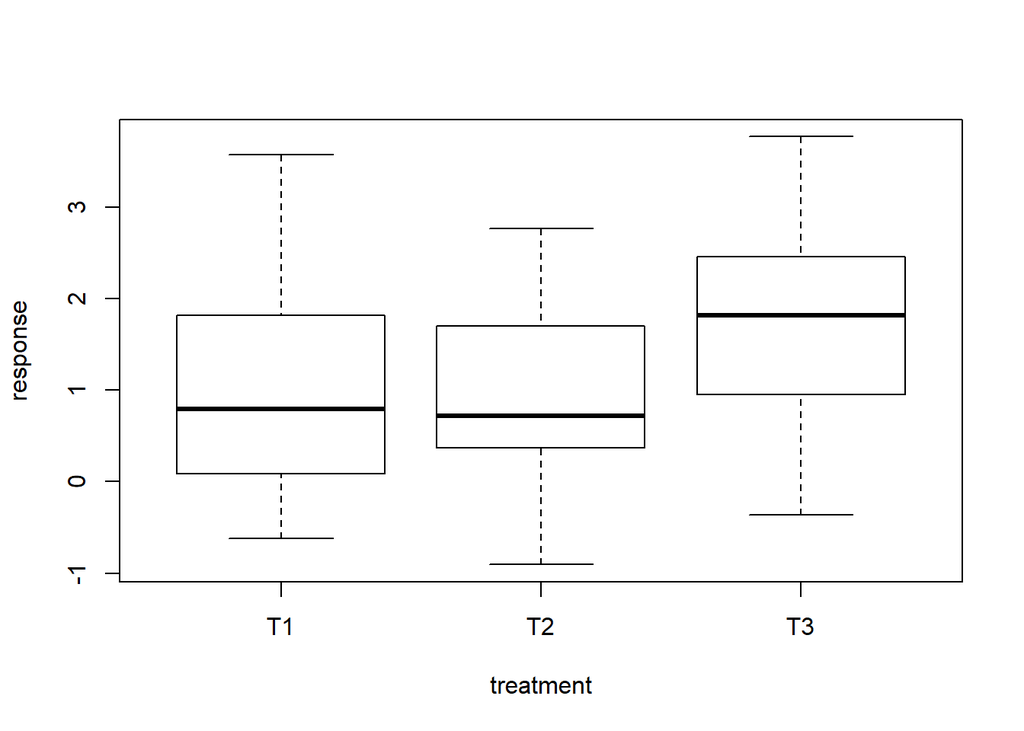

```r
# visualize data w/ boxplot
boxplot(response~treatment,data=my.df)
```

```r
model <- aov(response~treatment,data=my.df)
```

### s2: check data meet model assumptions of linearity and homoscedasticity, and if resids of model are norm dist

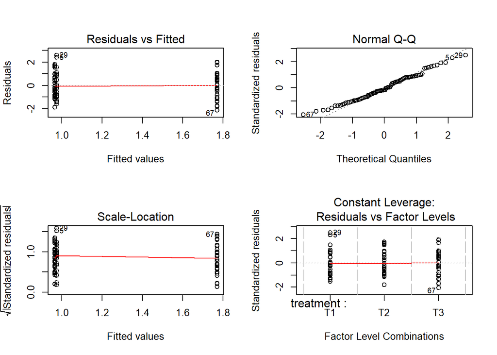

```r
par(mfrow=c(2,2))
plot(model)
```

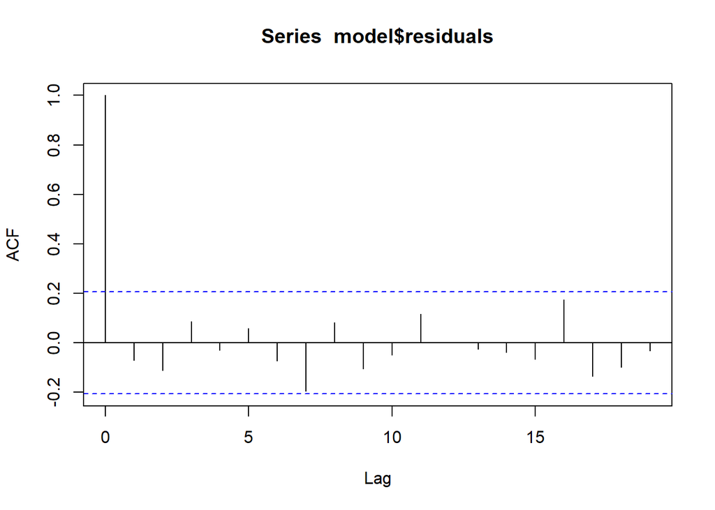

```r
#resid v fitted: linearity - red line flat. homoscedasticity - no wedge in resids
#normal qq-plot: data following 1:1 line is normal dist
#scale-location: no obv. trend
#resids leverage: helps identify influential data pts.
  #outliest can be influential but not necessarily
  #some pts in normal range can also be influential
  #look for pts. at extremes, outside dashed line (cook's dst)

#acf plot checks for autocorrelation
par(mfrow=c(1,1))
acf(model$residuals)
```

### s3: look at model output

```r
#get anove table
summary(model)
```

```
##             Df Sum Sq Mean Sq F value  Pr(>F)
## treatment    2  12.83   6.414   5.732 0.00459 **
## Residuals   87  97.36   1.119
## ---
## Signif. codes:  0 '***' 0.001 '**' 0.01 '*' 0.05 '.' 0.1 ' ' 1
```

interpret: we see significant effect of treatment, but we do not know which levels differ from one another

### s4: post-hoc comparisons

use tukeyhsd

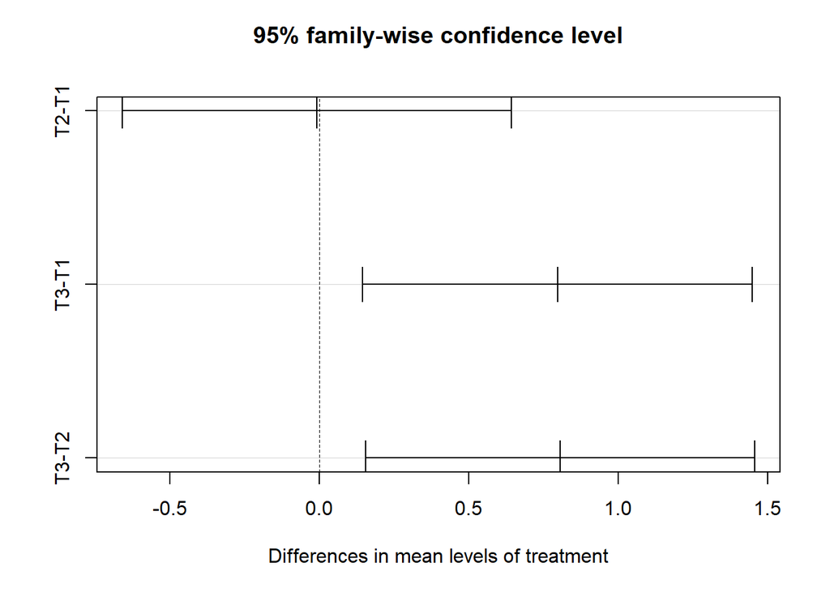

```r
mod.tukey <- TukeyHSD(model)
plot(mod.tukey)
```

use multcompView to get labels for our treatments. each letter represents group of data with same mean

```r
#install.packages('multcompView')
require(multcompView) #tells if package DNE
str(mod.tukey)
```

```
## List of 1
##  $ treatment: num [1:3, 1:4] -0.00895 0.79639 0.80534 -0.66026 0.14508 ...
##   ..- attr(*, "dimnames")=List of 2
##   .. ..$ : chr [1:3] "T2-T1" "T3-T1" "T3-T2"
##   .. ..$ : chr [1:4] "diff" "lwr" "upr" "p adj"
##  - attr(*, "class")= chr [1:2] "TukeyHSD" "multicomp"
##  - attr(*, "orig.call")= language aov(formula = response ~ treatment, data = my.df)
##  - attr(*, "conf.level")= num 0.95
##  - attr(*, "ordered")= logi FALSE
```

```r
labels <- multcompLetters(mod.tukey$treatment[,"p adj"])$Letters
str(labels)
```

```
##  Named chr [1:3] "a" "b" "a"
##  - attr(*, "names")= chr [1:3] "T2" "T3" "T1"
```

# Activities

## t1: identify promising biological control agents

```r
d1 <- read.csv("ANOVA_dataset1.csv")
head(d1)
```

```
##   treatment mortality
## 1   control  1.452878
## 2   control  3.266253
## 3   control  1.178652
## 4   control 13.400350
## 5   control  3.779183
## 6   control  1.196657
```

```r
levels(d1$treatment)
```

```
## [1] "control" "t1"      "t2"      "t3"      "t4"
```

```r
levels(d1$treatment) <- c("con","t1","t2","t3","t4") #rename control to con
```

### 1

H0: there is no diff. in mean mortality across all treatment and control groups Ha: there is a diff. in mean mortality across all treatment and control groups

### 2

plot data to check assumptions -hist() to determine mortality normal dist.

```r
str(d1)
```

```
## 'data.frame':    150 obs. of  2 variables:
##  $ treatment: Factor w/ 5 levels "con","t1","t2",..: 1 1 1 1 1 1 1 1 1 1 ...
##  $ mortality: num  1.45 3.27 1.18 13.4 3.78 ...
```

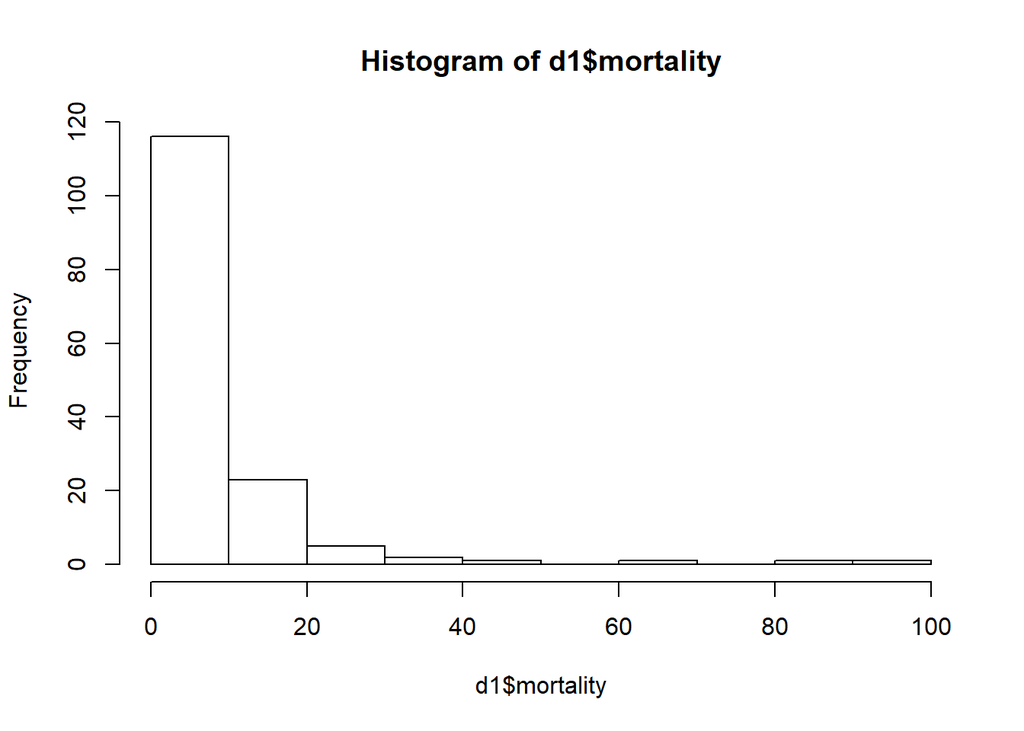

```r
hist(d1$mortality) #not normal: extreme skew to low mort vals
```

### 3

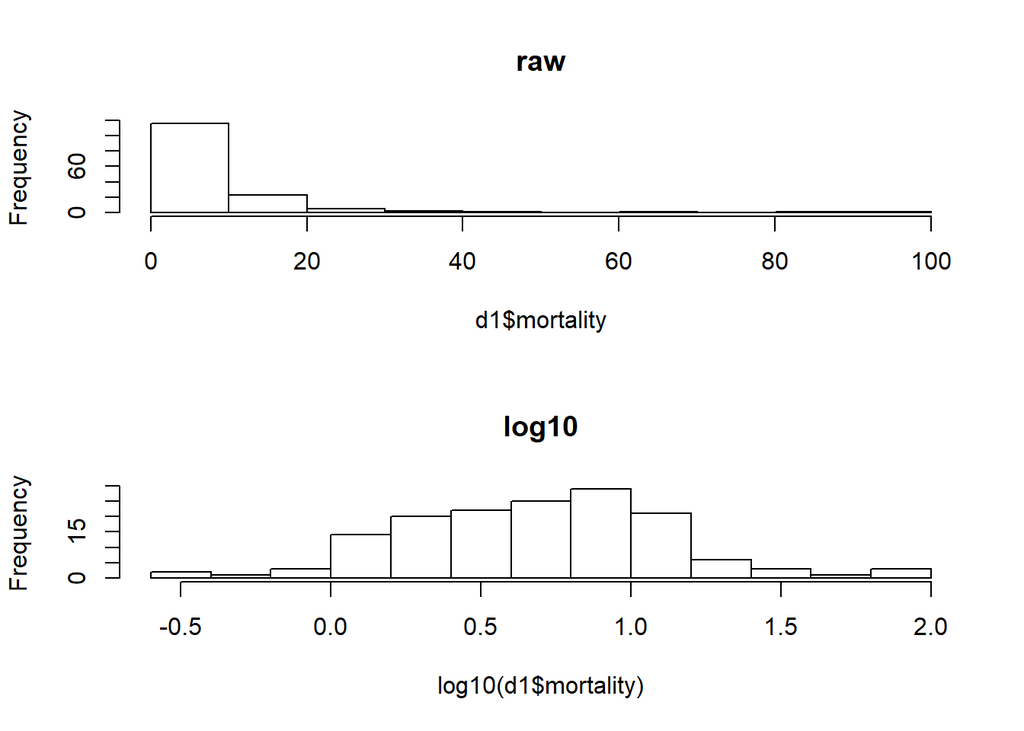

```r
par(mfrow=c(2,1))
hist(d1$mortality, main="raw")
hist(log10(d1$mortality),main="log10")
```

transformation necessary, transformed data normal

### 4

```r
mod1 <- aov(log10(mortality)~treatment,data=d1)
summary(mod1)
```

```
##              Df Sum Sq Mean Sq F value   Pr(>F)
## treatment     4  6.316  1.5790   10.36 2.07e-07 ***
## Residuals   145 22.093  0.1524
## ---
## Signif. codes:  0 '***' 0.001 '**' 0.01 '*' 0.05 '.' 0.1 ' ' 1
```

### 6

ans: conducting t-tests between each pair of means would inflate family-wise type I error rate (i.e, alpha), and this inflationary effect increasesd with number of t-tests performed. the more t-tests ran, more likely to get false positive. in contrast, tukey-kramer maintains type I error rate.

### 7

```r
mod.tukey1 <- TukeyHSD(mod1)
```

### 8

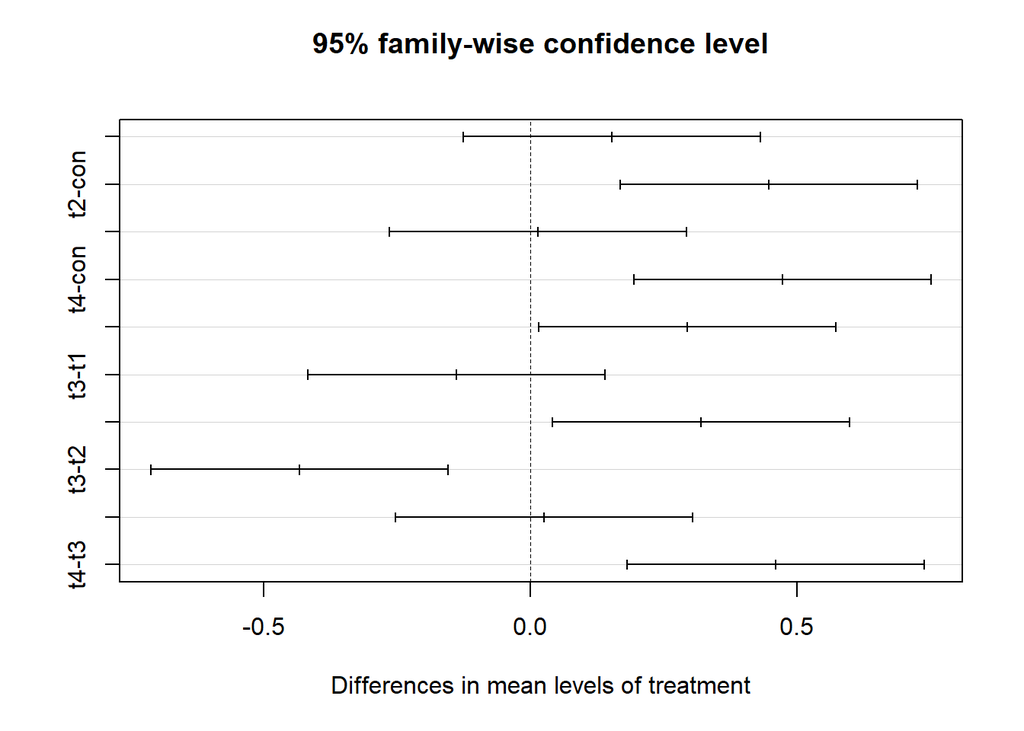

```r
par(mfrow=c(1,1))
plot(mod.tukey1)
```

```r
#fig shows diff. in means(x) between pairs of groups (y)
#error bars 95% ci around true mean diff between treat groups
```

interp; - error bars 95% ci - differences whose CIs overlap 0 indicate group means not statistically diff. -ex: mean mort. t4>t3, t2>con

### 9

```r
require(multcompView)
```

### 10

```r
labels1 <- multcompLetters(mod.tukey1$treatment[,"p adj"])$Letters
labels1 <- labels1[order(names(labels1))]
```

### 11

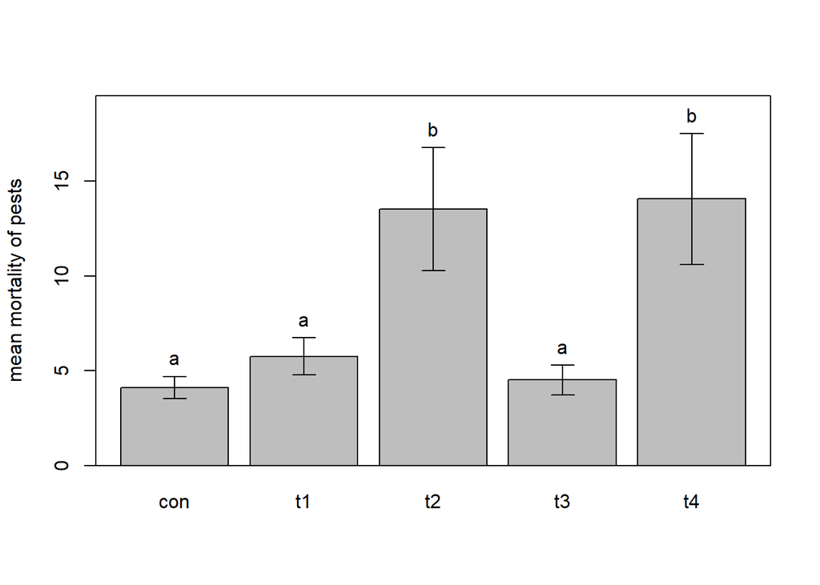

```r
means1 <- aggregate(mortality~treatment,mean,data=d1)
se.fun <- function(x){
  sd(x)/sqrt(length(x))
}
stderrs1 <- aggregate(mortality ~ treatment, FUN = se.fun, data = d1)

bp <- barplot(means1$mortality,names=means1$treatment,ylab="mean mortality of pests", ylim=range(c(0,max(means1$mortality+stderrs1$mortality)+2)))
arrows(x0=bp,x1=bp,y0=means1$mortality - stderrs1$mortality, y1=means1$mortality + stderrs1$mortality, code=3, angle=90, length=0.1)
box()

text(x=bp,y=means1$mortality+stderrs1$mortality,labels1,pos=3)
```

### adv coding q

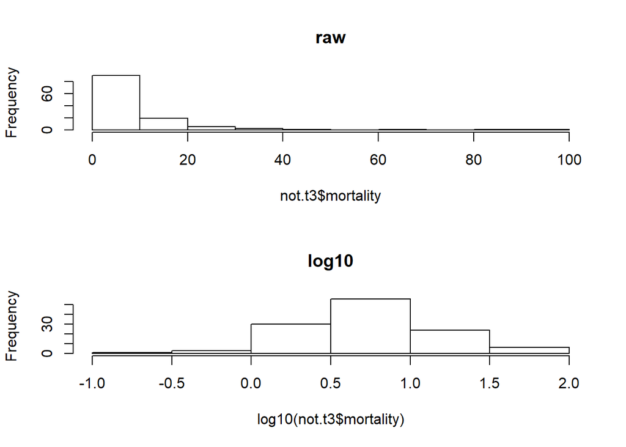

```r
#p1
not.t3 <- subset(d1, !treatment == "t3", drop = FALSE)

#p2
par(mfrow=c(2,1))
hist(not.t3$mortality, main="raw")
hist(log10(not.t3$mortality),main="log10")
```

```r
modnt3 <- aov(mortality~treatment,data=not.t3) #not transformed due to answer key error
summary(modnt3)
```

```
##              Df Sum Sq Mean Sq F value  Pr(>F)
## treatment     3   2394   798.0    4.49 0.00509 **
## Residuals   116  20615   177.7
## ---
## Signif. codes:  0 '***' 0.001 '**' 0.01 '*' 0.05 '.' 0.1 ' ' 1
```

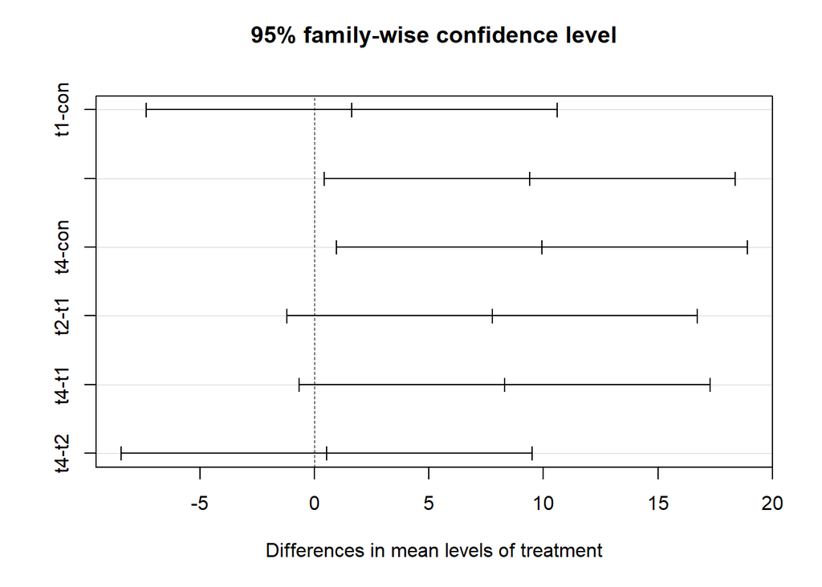

```r
mod.tukeynt3 <- TukeyHSD(modnt3)
par(mfrow=c(1,1))
plot(mod.tukeynt3)
```

## t2: mitig impacts on pest enemies

```r
d2 <- read.csv("ANOVA_dataset2.csv")
```

### 1

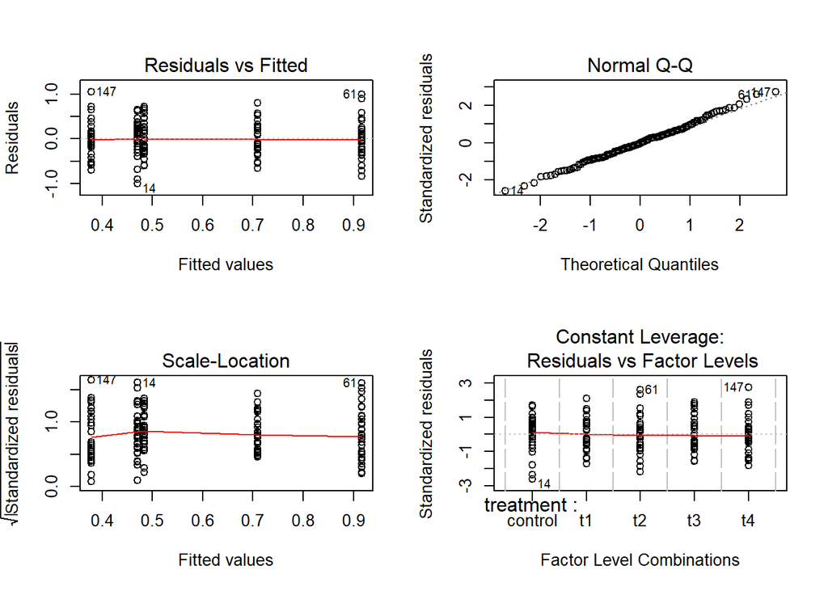

```r
mod2 <- aov(log10(mortality) ~ treatment, data = d2)
par(mfrow=c(2,2))
plot(mod2)
```

```r
summary(mod2)
```

[output not shown]

interp:yes, there is diff in mean mort of pred/enemy across diff treat groups (p-val<0.05)

### 2

```r
mod.tukey2 <- TukeyHSD(mod2)
```

### 3

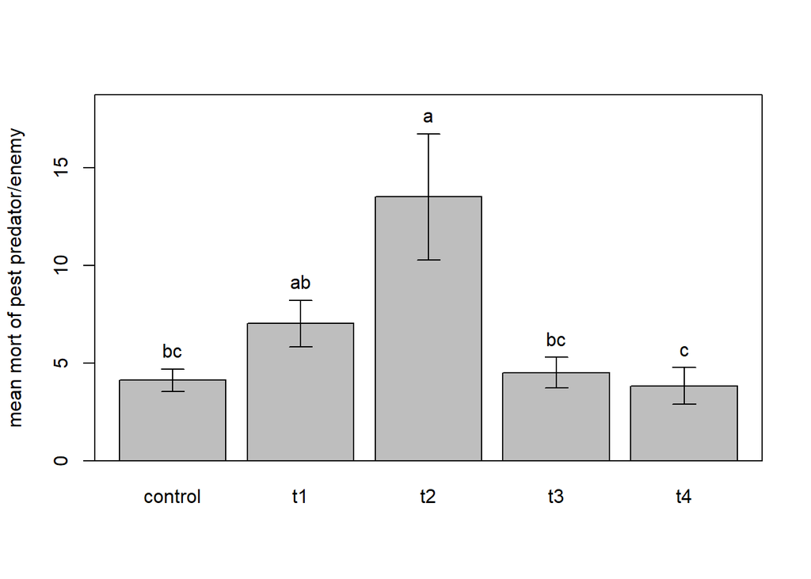

```r
par(mfrow=c(1,1))
means2 <- aggregate(mortality~treatment,mean,data=d2)
stderrs2 <- aggregate(mortality~treatment,FUN=se.fun,data=d2)
bp <- barplot(means2$mortality,names=means2$treatment,ylab="mean mort of pest predator/enemy", ylim=range(c(0,max(means2$mortality+stderrs2$mortality)+2)))
arrows(x0=bp,x1=bp,y0=means2$mortality-stderrs2$mortality,y1=means2$mortality+stderrs2$mortality,code=3,angle=90,length=0.1)
box()

labels2 <- multcompLetters(mod.tukey2$treatment[,"p adj"])$Letters
labels2 <- labels2[c("control","t1","t2","t3","t4")]
text(x=bp,y=means2$mortality+stderrs2$mortality,labels2,pos=3)
```

### 4

a is not diff from ab but diff from bc

Mean mortality of the enemy/ predator of the pest was highest for t2

Mean mortality of the enemy/predator for t1 was not significantly different from that of the control group or t2

### 5

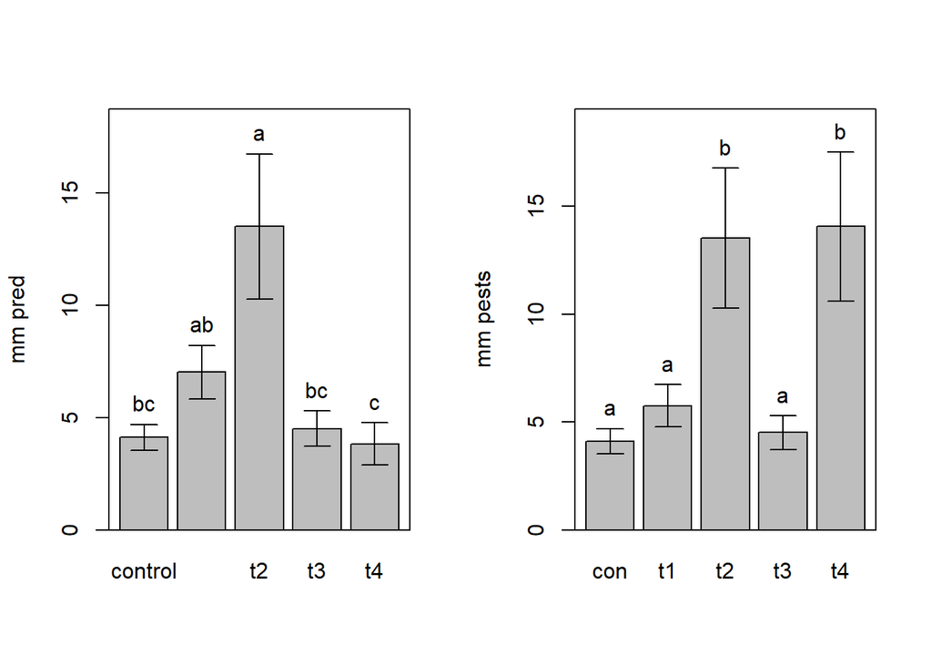

```r
par(mfrow=c(1,2))

bp <- barplot(means2$mortality,names=means2$treatment,ylab="mm pred", ylim=range(c(0,max(means2$mortality+stderrs2$mortality)+2)))
arrows(x0=bp,x1=bp,y0=means2$mortality-stderrs2$mortality,y1=means2$mortality+stderrs2$mortality,code=3,angle=90,length=0.1)
box()
labels2 <- multcompLetters(mod.tukey2$treatment[,"p adj"])$Letters
labels2 <- labels2[c("control","t1","t2","t3","t4")]
text(x=bp,y=means2$mortality+stderrs2$mortality,labels2,pos=3)

bp <- barplot(means1$mortality,names=means1$treatment,ylab="mm pests", ylim=range(c(0,max(means1$mortality+stderrs1$mortality)+2)))
arrows(x0=bp,x1=bp,y0=means1$mortality - stderrs1$mortality, y1=means1$mortality + stderrs1$mortality, code=3, angle=90, length=0.1)
box()
text(x=bp,y=means1$mortality+stderrs1$mortality,labels1,pos=3)
```

```r
# how is b right?
```